# Wilson Replication Analysis

# Libraries

```r
library(reshape2)
library(Hmisc)
library(dplyr)
library(ggplot2)
library(digest)
library(effsize)
```

# Deidentify

First, we’ll deidentify the data (salt and hash) and work with that

```r
d <- read.csv("~/Wilson-2014-just-think-replication/data/identified/HITResultsFor3VADEH0UHCXATAPEJ7DOH8HDMOJPSJ_3.csv", stringsAsFactors=F)
salt <- read.csv("~/Wilson-2014-just-think-replication/data/identified/salt.csv", stringsAsFactors=F, header = FALSE)[1,1]
d$id <- paste(d$WorkerId, salt, sep="") #salt
d$id <- unlist(lapply( d$id, function(id){ digest(id, algo="sha256" ) } )) #hash
d <- select(d,-c(HitId:Status, Answer.1)) # delete MTurk Id and other extra info
d <- d[order(d$id),] # reorder to not be identifiable with originals
#  write the deidentified files to the shared folder
write.csv(d,"~/Wilson-2014-just-think-replication/data/data.csv", row.names=F)
```

# Data Formatting

First we set the data up for easy analysis. Basically, this gets all the questions that were answered by the participant, and puts them in long form.

```r
d <- read.csv("~/Wilson-2014-just-think-replication/data/data.csv", stringsAsFactors=F)

da <- data.frame(id=character(),
                 variable=character(),
                 value=character())

# delete participant with no data
d <- d[!d$AcceptTime=="",]

for(n in 1:nrow(d)) {
  p <- d[n,] # get one participant
  pat <- '.*question":"(.*)","answer.*' # get question name
  p_ans <- p[grepl(pat, p)] # get only those answered
  names(p_ans) <- sub(pat, "\\1", p_ans)

  pat2 <- '.*answer":(.*)}'
  p_ans[1,] <- sub(pat2, "\\1", p_ans)
  p_ans[1,] <- gsub("\\n", ' & ', p_ans, fixed=T) # separate activities
  p_ans[1,] <- gsub("[[:punct:]]", '', p_ans)

  # merge with id
  p_ans$id <- d[n,"id"]

  p_m <- melt(p_ans, id.vars="id")

  da <- rbind(da,p_m)
}
# variable is somehow a factor now, so let's change back to character
da$variable <- as.character(da$variable)
# only grad the time period of the free period
da$variable[grep("time_free-period",da$variable)] <- "timeFreePeriod"
# and get rid of time for now, and we could add back in if we want to take a look
da <- da[! grepl("time_", da$variable),]
#table(da$id) # how many answers per participant?
```

# Create Checks

## Window checks

```r
# da[grepl("windowCheck_", da$variable) & !duplicated(da$value),]
wChecks <- da %>% filter(grepl("windowCheck_", variable)) %>% # get windowChecks
  group_by(id) %>%
  mutate(false = grepl("false",value)) %>%
  summarise(num = length(unique(value)),
            falses = sum(false))

#get ids that don't pass window check (not active) - should only be for think condition
fail_window <- wChecks %>% filter(falses > 6)
fail_window <- fail_window$id
# get rid of window checks to be more manageable data
da <- da %>% filter(!grepl("windowCheck_", variable))
```

## Cast to wide form and make numeric

```r
dm <- dcast(da,id ~ variable)
```

And make numeric rows numeric

```r
smart_cast_numeric <- function(DF){
  numeric_DF <- DF
  for(i in 1:ncol(DF)){
    numeric_DF[,i] <- all.is.numeric(DF[,i], what = c( "vector"), extras=c('.','NA','',NA))
    }
    return(numeric_DF)
}
dm <- smart_cast_numeric(dm)
```

Update fail_window for only those in the thinking condition

```r
fail_window <- dm[dm$id %in% fail_window & dm$condition == "think","id"]
length(fail_window) # 13 failed window check
```

```
## [1] 13
```

## 12 minute check

```r
timeChecks <- dm %>% filter(is.na(timeFreePeriod)) # went more than 71 checks

# get ids that don't pass time check
fail_time <- unique(timeChecks$id)
length(fail_time) # 9 failed time check
```

```
## [1] 9
```

## Manipulation check

Did they respond that they did the activities asked?

```r
# find if their condition matches what they think their condition was
fail_manip <- dm[dm$condition != dm$manipCheck,"id"]
length(fail_manip) # 15 failed time check
```

```
## [1] 15
```

## Activities check

Did they do any of the activities they weren’t supposed to?

```r
disallowed_active <- c("asleep","phonetalk","phonetext","imchat","email","talk","work")
disallowed_think <- c(disallowed_active,"openwindow","videogame","read","puzzle","tvmovie","music","write")
d_think <- lapply(dm[,disallowed_think],function(x){sum(x) >2})
fail_think <- dm[dm$condition == "think" & rowSums(dm[,disallowed_think]) >2,"id"]
fail_active <- dm[dm$condition == "active" & rowSums(dm[,disallowed_active]) >2,"id"]
fail_cond <- c(fail_think,fail_active)
```

# Limiting the data

## Original

Criteria:

1. Participants did not spend more than 12 minutes on the task, indicating they were at their computer

```r
table(dm$id %in% fail_time,dm$condition) #which failed by condition?
```

```
##
##         active think
##   FALSE     37    44
##   TRUE       6     3
```

```r
dm1 <- dm %>% filter(!id %in% fail_time) # save new analysis dataframe
dm$limit_orig <- !dm$id %in% fail_time
```

## Strict

Criteria:

1. Participants did not spend more than 12 minutes on the task, indicating they were at their computer
2. Participants in the thinking condition did not resize their window
3. Participants knew what condition they were in
4. Participants spent less than 2 minutes on something they were not supposed to (based on condition)

```r
fail_all <- unique(c(fail_time,fail_window,fail_manip,fail_cond))
table(dm$id %in% fail_all,dm$condition) #which failed by condition?
```

```
##
##         active think
##   FALSE     30    23
##   TRUE      13    24
```

```r
dm2 <- dm %>% filter(!id %in% fail_all) # save new analysis dataframe
dm$limit_strict <- !dm$id %in% fail_all
```

## Save formatted dataframe

```r
write.csv(dm,"~/Wilson-2014-just-think-replication/data/data_formatted.csv", row.names=F)
```

# Original Analysis

### Enjoyment plot and t-test

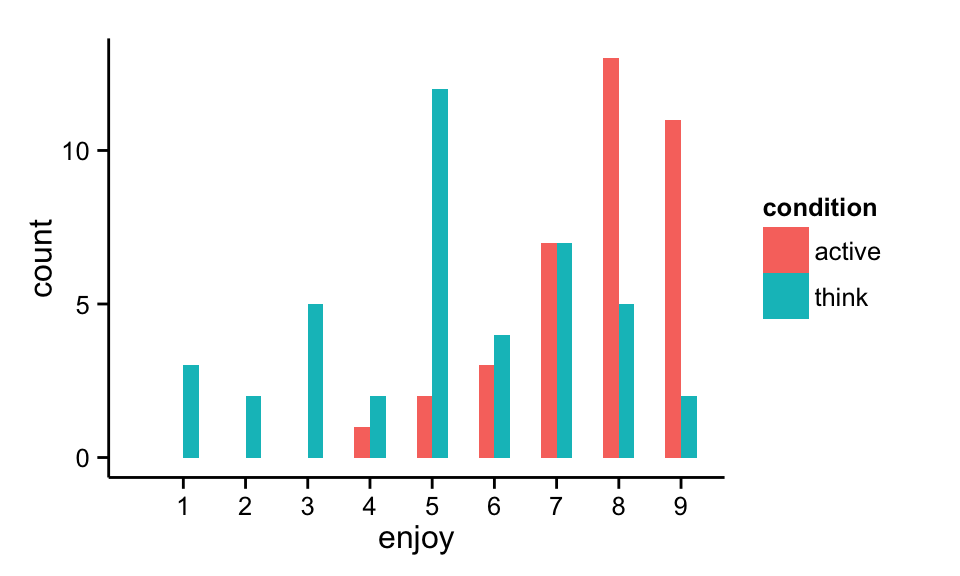

```r
ggplot(dm1,aes(x=enjoy, fill=condition)) +
  geom_histogram(position="dodge", binwidth=.5) +
  theme_classic() +
  scale_x_continuous(breaks=c(1.25:9.25), labels=c(1:9))
```

```r
t.test(enjoy ~ condition, dm1, var.equal=TRUE)
```

```
##
##  Two Sample t-test
##
## data:  enjoy by condition
## t = 5.892, df = 77, p-value = 9.498e-08
## alternative hypothesis: true difference in means is not equal to 0
## 95 percent confidence interval:
##  1.598 3.230
## sample estimates:
## mean in group active  mean in group think
##                7.676                5.262
```

```r
t.test(enjoy ~ condition, dm1, var.equal=FALSE)
```

```
##
##  Welch Two Sample t-test
##
## data:  enjoy by condition
## t = 6.075, df = 67.99, p-value = 6.281e-08
## alternative hypothesis: true difference in means is not equal to 0
## 95 percent confidence interval:
##  1.621 3.207
## sample estimates:
## mean in group active  mean in group think
##                7.676                5.262
```

```r
var.test(enjoy ~ condition, dm1)
```

```
##
##  F test to compare two variances
##
## data:  enjoy by condition
## F = 0.3527, num df = 36, denom df = 41, p-value = 0.001947
## alternative hypothesis: true ratio of variances is not equal to 1
## 95 percent confidence interval:
##  0.1867 0.6751
## sample estimates:
## ratio of variances
##             0.3527
```

```r
cohen.d(dm1$enjoy,dm1$condition,pooled=TRUE,paired=FALSE,
        na.rm=TRUE)
```

```
##
## Cohen's d
##
## d estimate: 1.328 (large)
## 95 percent confidence interval:
##   inf   sup
## 0.825 1.832
```

### Mind Wandering plot and t-test

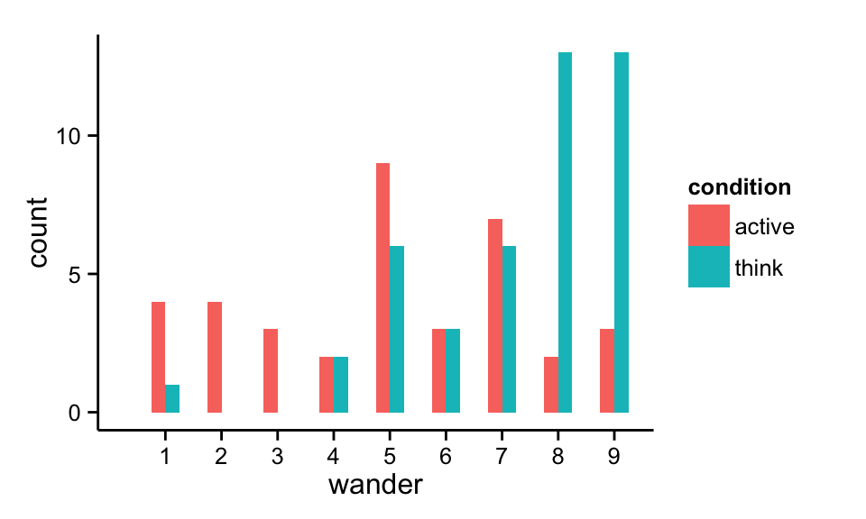

```r
ggplot(dm1,aes(x=wander, fill=condition)) +
  geom_histogram(position="dodge", binwidth=.5) +
  theme_classic() +
  scale_x_continuous(breaks=c(1.25:9.25), labels=c(1:9))
```

```r
t.test(wander ~ condition, dm1, var.equal=TRUE)
```

```
##
##  Two Sample t-test
##
## data:  wander by condition
## t = -4.873, df = 79, p-value = 5.568e-06
## alternative hypothesis: true difference in means is not equal to 0
## 95 percent confidence interval:
##  -3.239 -1.360
## sample estimates:
## mean in group active  mean in group think
##                4.973                7.273
```

```r
t.test(wander ~ condition, dm1, var.equal=FALSE)
```

```
##
##  Welch Two Sample t-test
##
## data:  wander by condition
## t = -4.756, df = 65.94, p-value = 1.115e-05
## alternative hypothesis: true difference in means is not equal to 0
## 95 percent confidence interval:
##  -3.265 -1.334
## sample estimates:
## mean in group active  mean in group think
##                4.973                7.273
```

```r
var.test(wander ~ condition, dm1)
```

```
##
##  F test to compare two variances
##
## data:  wander by condition
## F = 1.766, num df = 36, denom df = 43, p-value = 0.07497
## alternative hypothesis: true ratio of variances is not equal to 1
## 95 percent confidence interval:
##  0.9437 3.3633
## sample estimates:
## ratio of variances
##              1.766
```

```r
cohen.d(dm1$wander,dm1$condition,pooled=TRUE,paired=FALSE,
        na.rm=TRUE)
```

```
##
## Cohen's d
##
## d estimate: -1.087 (large)
## 95 percent confidence interval:
##     inf     sup
## -1.5690 -0.6047
```

### Difficulty Concentrating plot and t-test

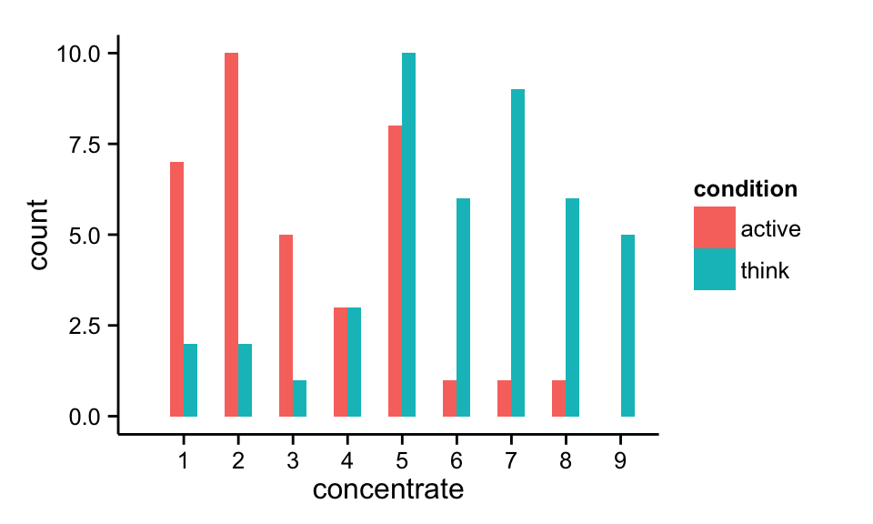

```r
ggplot(dm1,aes(x=concentrate, fill=condition)) +
  geom_histogram(position="dodge", binwidth=.5) +
  theme_classic() +
  scale_x_continuous(breaks=c(1.25:9.25), labels=c(1:9))
```

```r
t.test(concentrate ~ condition, dm1, var.equal=TRUE)
```

```
##
##  Two Sample t-test
##
## data:  concentrate by condition
## t = -6.185, df = 78, p-value = 2.664e-08
## alternative hypothesis: true difference in means is not equal to 0
## 95 percent confidence interval:
##  -3.679 -1.887
## sample estimates:
## mean in group active  mean in group think
##                3.194                5.977
```

```r
t.test(concentrate ~ condition, dm1, var.equal=FALSE)
```

```
##
##  Welch Two Sample t-test
##
## data:  concentrate by condition
## t = -6.262, df = 77.5, p-value = 1.958e-08
## alternative hypothesis: true difference in means is not equal to 0
## 95 percent confidence interval:
##  -3.668 -1.898
## sample estimates:
## mean in group active  mean in group think
##                3.194                5.977
```

```r
var.test(concentrate ~ condition, dm1)
```

```
##
##  F test to compare two variances
##
## data:  concentrate by condition
## F = 0.7825, num df = 35, denom df = 43, p-value = 0.4582
## alternative hypothesis: true ratio of variances is not equal to 1
## 95 percent confidence interval:
##  0.4168 1.5006
## sample estimates:
## ratio of variances
##             0.7825
```

```r
cohen.d(dm1$concentrate,dm1$condition,pooled=TRUE,paired=FALSE,
        na.rm=TRUE)
```

```
##
## Cohen's d
##
## d estimate: -1.39 (large)
## 95 percent confidence interval:
##     inf     sup
## -1.8957 -0.8844
```

# Strict Analysis

### Enjoyment plot and t-test

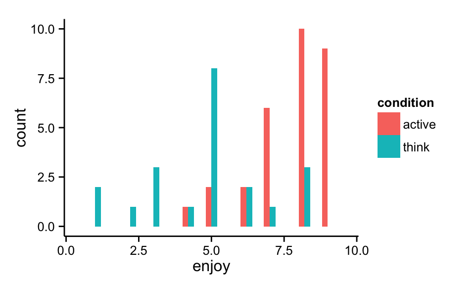

```r
ggplot(dm2,aes(x=enjoy, fill=condition)) +
  geom_histogram(position="dodge", binwidth=.4) +
  theme_classic()
```

```r
t.test(enjoy ~ condition, dm2, var.equal=TRUE)
```

```
##
##  Two Sample t-test
##
## data:  enjoy by condition
## t = 5.997, df = 49, p-value = 2.367e-07
## alternative hypothesis: true difference in means is not equal to 0
## 95 percent confidence interval:
##  1.909 3.834
## sample estimates:
## mean in group active  mean in group think
##                7.633                4.762
```

```r
t.test(enjoy ~ condition, dm2, var.equal=FALSE)
```

```
##
##  Welch Two Sample t-test
##
## data:  enjoy by condition
## t = 5.576, df = 31.75, p-value = 3.812e-06
## alternative hypothesis: true difference in means is not equal to 0
## 95 percent confidence interval:
##  1.822 3.921
## sample estimates:
## mean in group active  mean in group think
##                7.633                4.762
```

```r
var.test(enjoy ~ condition, dm2)
```

```
##
##  F test to compare two variances
##
## data:  enjoy by condition
## F = 0.4257, num df = 29, denom df = 20, p-value = 0.03531
## alternative hypothesis: true ratio of variances is not equal to 1
## 95 percent confidence interval:
##  0.1806 0.9421
## sample estimates:
## ratio of variances
##             0.4257
```

```r
cohen.d(dm2$enjoy,dm2$condition,pooled=TRUE,paired=FALSE,
        na.rm=TRUE)
```

```
##
## Cohen's d
##
## d estimate: 1.706 (large)
## 95 percent confidence interval:
##   inf   sup
## 1.024 2.388
```

### Mind Wandering plot and t-test

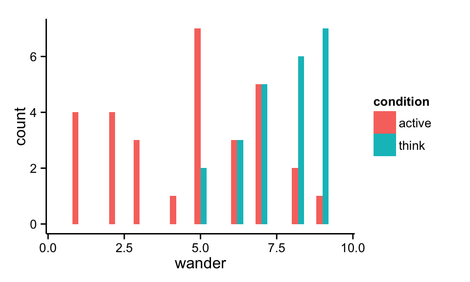

```r
ggplot(dm2,aes(x=wander, fill=condition)) +
  geom_histogram(position="dodge", binwidth=.4) +
  theme_classic()
```

```r
t.test(wander ~ condition, dm2, var.equal=TRUE)
```

```
##
##  Two Sample t-test
##
## data:  wander by condition
## t = -5.365, df = 51, p-value = 1.99e-06
## alternative hypothesis: true difference in means is not equal to 0
## 95 percent confidence interval:
##  -4.075 -1.856
## sample estimates:
## mean in group active  mean in group think
##                4.600                7.565
```

```r
t.test(wander ~ condition, dm2, var.equal=FALSE)
```

```
##
##  Welch Two Sample t-test
##
## data:  wander by condition
## t = -5.768, df = 46.72, p-value = 6.144e-07
## alternative hypothesis: true difference in means is not equal to 0
## 95 percent confidence interval:
##  -4.000 -1.931
## sample estimates:
## mean in group active  mean in group think
##                4.600                7.565
```

```r
var.test(wander ~ condition, dm2)
```

```
##
##  F test to compare two variances
##
## data:  wander by condition
## F = 3.329, num df = 29, denom df = 22, p-value = 0.005001
## alternative hypothesis: true ratio of variances is not equal to 1
## 95 percent confidence interval:
##  1.46 7.26
## sample estimates:
## ratio of variances
##              3.328
```

```r
cohen.d(dm2$wander,dm2$condition,pooled=TRUE,paired=FALSE,
        na.rm=TRUE)
```

```
##
## Cohen's d
##
## d estimate: -1.487 (large)
## 95 percent confidence interval:
##     inf     sup
## -2.1291 -0.8445
```

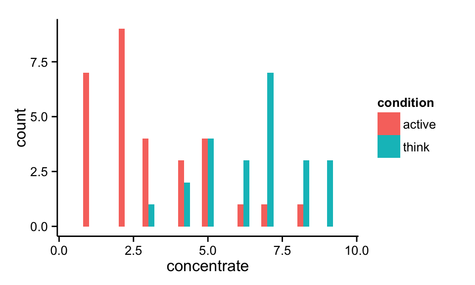

```r
ggplot(dm2,aes(x=concentrate, fill=condition)) +
  geom_histogram(position="dodge", binwidth=.4) +
  theme_classic()
```

```r
t.test(concentrate ~ condition, dm2, var.equal=TRUE)
```

```
##
##  Two Sample t-test
##
## data:  concentrate by condition
## t = -6.92, df = 51, p-value = 7.277e-09
## alternative hypothesis: true difference in means is not equal to 0
## 95 percent confidence interval:
##  -4.487 -2.469
## sample estimates:
## mean in group active  mean in group think
##                3.000                6.478
```

```r
t.test(concentrate ~ condition, dm2, var.equal=FALSE)
```

```
##
##  Welch Two Sample t-test
##
## data:  concentrate by condition
## t = -7.044, df = 50.03, p-value = 5.113e-09
## alternative hypothesis: true difference in means is not equal to 0
## 95 percent confidence interval:
##  -4.470 -2.486
## sample estimates:
## mean in group active  mean in group think
##                3.000                6.478
```

```r
var.test(concentrate ~ condition, dm2)
```

```
##
##  F test to compare two variances
##
## data:  concentrate by condition
## F = 1.302, num df = 29, denom df = 22, p-value = 0.5279
## alternative hypothesis: true ratio of variances is not equal to 1
## 95 percent confidence interval:
##  0.5712 2.8409
## sample estimates:
## ratio of variances
##              1.302
```

```r
cohen.d(dm2$concentrate,dm2$condition,pooled=TRUE,paired=FALSE,
        na.rm=TRUE)
```

```
##
## Cohen's d
##
## d estimate: -1.918 (large)
## 95 percent confidence interval:
##    inf    sup
## -2.605 -1.230
```

# Make some simple plots

## Get means and sd’s

```r
dm1_summ <- dm1 %>% group_by(condition) %>%
  summarise(wander_mean = round(mean(wander,na.rm=T),2),
                              enjoy_mean = round(mean(enjoy,na.rm=T),2),
                              concentrate_mean = round(mean(concentrate,na.rm=T),2),
                              wander_sd = round(sd(wander,na.rm=T),2),
                              enjoy_sd = round(sd(enjoy,na.rm=T),2),
                              concentrate_sd = round(sd(concentrate,na.rm=T),2))
dm1_summ <- rbind(dm1_summ,c("orig_active",3.67,6.87,2.80,2.66,1.91,2.01))
dm1_summ <- rbind(dm1_summ,c("orig_think",6.67,3.20,6.07,1.80,2.23,2.28))

dm2_summ <- dm2 %>% group_by(condition) %>%
  summarise(wander_mean = round(mean(wander,na.rm=T),2),
                              enjoy_mean = round(mean(enjoy,na.rm=T),2),
                              concentrate_mean = round(mean(concentrate,na.rm=T),2),
                              wander_sd = round(sd(wander,na.rm=T),2),
                              enjoy_sd = round(sd(enjoy,na.rm=T),2),
                              concentrate_sd = round(sd(concentrate,na.rm=T),2))
dm2_summ <- rbind(dm2_summ,c("orig_active",3.67,6.87,2.80,2.66,1.91,2.01))
dm2_summ <- rbind(dm2_summ,c("orig_think",6.67,3.20,6.07,1.80,2.23,2.28))
```

### Wilcox tests

```r
wilcox.test(enjoy ~ condition, dm1)
```

```
##
##  Wilcoxon rank sum test with continuity correction
##
## data:  enjoy by condition
## W = 1284, p-value = 4.459e-07
## alternative hypothesis: true location shift is not equal to 0
```

```r
wilcox.test(wander ~ condition, dm1)
```

```
##
##  Wilcoxon rank sum test with continuity correction
##
## data:  wander by condition
## W = 365, p-value = 1.654e-05
## alternative hypothesis: true location shift is not equal to 0
```

```r
wilcox.test(concentrate ~ condition, dm1)
```

```
##
##  Wilcoxon rank sum test with continuity correction
##
## data:  concentrate by condition
## W = 268.5, p-value = 3.215e-07
## alternative hypothesis: true location shift is not equal to 0
```

```r
wilcox.test(enjoy ~ condition, dm2)
```

```
##
##  Wilcoxon rank sum test with continuity correction
##
## data:  enjoy by condition
## W = 549.5, p-value = 5.278e-06
## alternative hypothesis: true location shift is not equal to 0
```

```r
wilcox.test(wander ~ condition, dm2)
```

```
##
##  Wilcoxon rank sum test with continuity correction
##
## data:  wander by condition
## W = 100.5, p-value = 9.656e-06
## alternative hypothesis: true location shift is not equal to 0
```

```r
wilcox.test(concentrate ~ condition, dm2)
```

```
##
##  Wilcoxon rank sum test with continuity correction
##
## data:  concentrate by condition
## W = 68.5, p-value = 5.903e-07
## alternative hypothesis: true location shift is not equal to 0
```

## Money shots Original

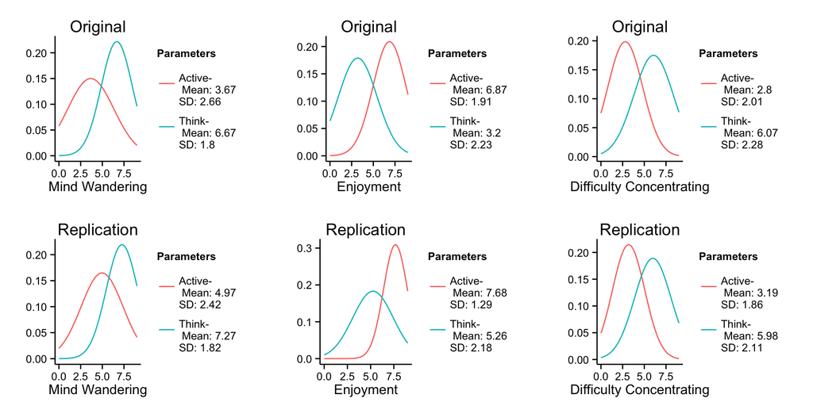

## Money shots Strict

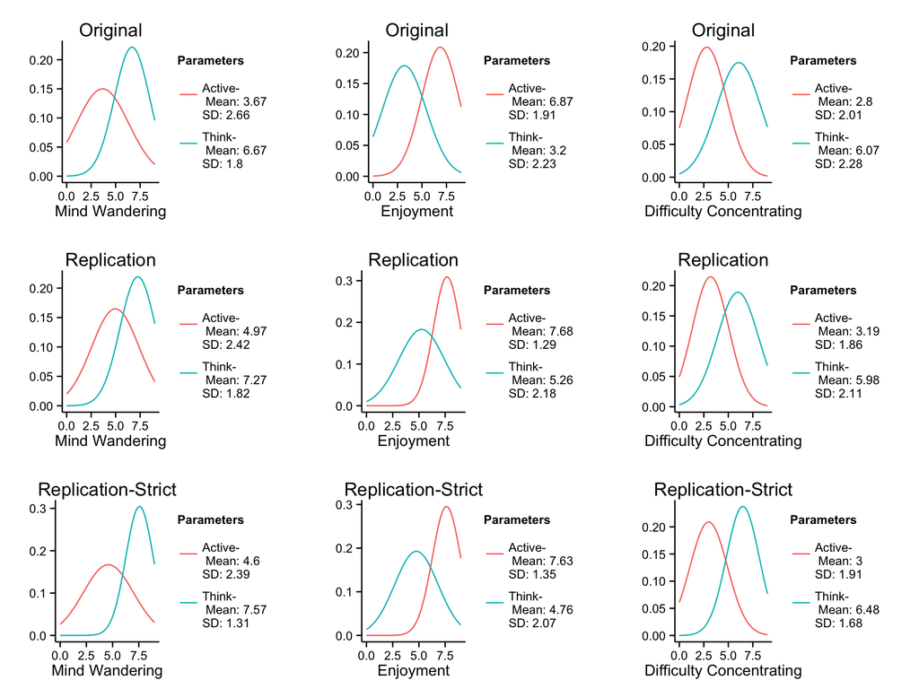